# Discrete Methods

W. Bauer

12/18/2014

### Discrete estimation of eigenvalues and spatial resolution

In a previous note, Spatial Resolution, a very simplified model of NIR transmission from cerebral cortex to scalp was shown to be a standard linear system, amounting to a 2D spatial low-pass filter with very small eigenvalues at spatial frequencies above 1 cycle/cm. This suggests that achieving spatial resolution of better than 1 cm will be challenging.

Of course, this simplified model’s main virtue is its simplicity. Its accuracy is very much open to question, but it may foreshadow potential problems in more realistic models.

In the previous note, accuracy of numerical integration was a limiting factor. This note uses a discrete form of the model, replacing integrals with sums, both in an attempt to avoid the integration issue and to facilitate quick numerical experiment.

[Nyquist’s Sampling Theorem](http://en.wikipedia.org/wiki/Nyquist–Shannon_sampling_theorem) implies that spatial resolution of 3 mm requires an array of detectors spaced at intervals no greater than 1.5 mm on a grid covering the entire area of scalp at which significant signal strength is expected. In what follows, a grid of 1 mm intervals is used.

A discrete model amenable to treatment with a fast Fourier transform, must be finite in spatial extent. Numerical integration shows that the 2D spatial filter derived previously has little relative weight beyond 128 mm from its center:$\frac{\int_{128}^{\infty}.92^{\sqrt{r^2 + b^2}}\frac{b}{4 \pi (r^2 + b^2)^{1.5}}rdr}{\int_0^{\infty}.92^{\sqrt{r^2 + b^2}}\frac{b}{4 \pi (r^2 + b^2)^{1.5}}rdr} = 1.88 \times 10^{-5}$A 256x256 grid will cover this radius. However, a fast Fourier transform operates on a periodic or circular grid. To avoid aliasing from wrap-around, linear dimensions should be doubled. Thus a 512x512 grid is used.

Since the spatial grid has 512 1 mm intervals in each dimension, the grid of a corresponding Fourier transform will be in units of 1/512 cycles/mm in each dimension. The spatial resolution of interest corresponds to 1/3 cycles/mm, hence to a point at position 512/3 = 171 on either dimension of the Fourier transform grid. The absolute value of the eigenvalue at such a point is 9.267515e-11. This is about 8 orders of magnitude below the maximum of 0.01178317. The precision of this small value is dubious as the following plot suggests, but it is clearly very small. The computation as a whole is accurate since the inverse transform matches the original to within 16 decimal places.

A representative eigenvalue corresponding to 10 mm resolution has absolute value 1.657966e-05 which is less than 3 orders of magnitude below the maximum, suggesting as in the previous note a limiting spatial resolution of 1 cm.

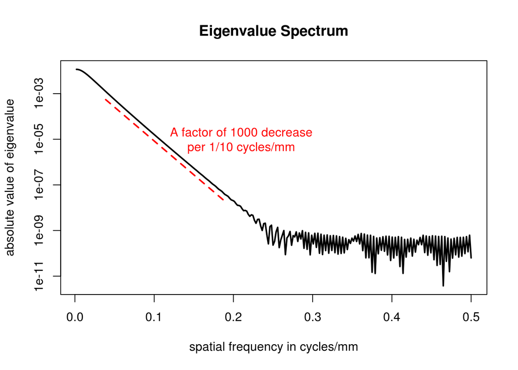

In the linear region of the spectrum, eigenvalue magnitudes decrease by a factor of 10 every 1/30 cycle/mm, or roughly 3 orders of magnitude per 1/10 of a cycle per mm.

### Checkerboard images

Most experiments using voltage sensitive dyes, monitor a fixed band of wavelengths. (See Leslie M. Loew [Design and Use of Organic Voltage Sensitive Dyes](http://scholar.google.com/scholar?q=Design+and+Use+of+Organic+Voltage+Sensitive+Dyes&btnG=Submit&hl=en&as_sdt=0%2C21).) Putative polarized and depolarized spectra of dyes which emit in near infrared are shown below. Suppose these spectra were realistic and that wavelengths exceeding 900 nm were monitored. The ratio of polarized to depolarized emission rates would then be 1.32.

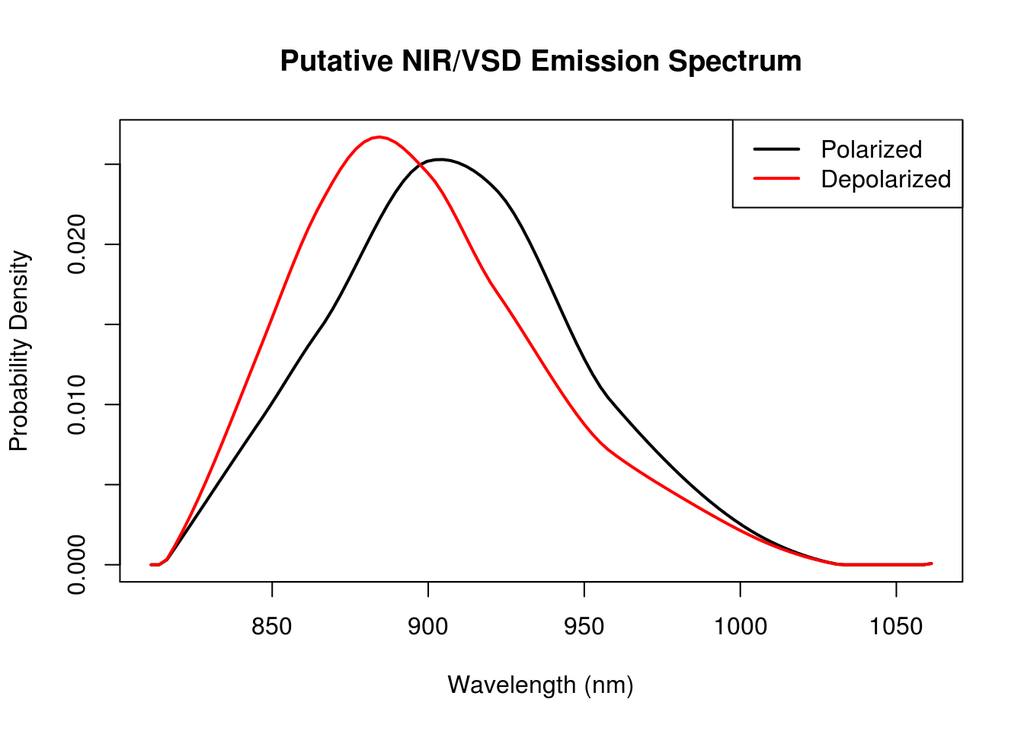

Consider a checkerboard pattern of alternating polarized and depolarized cells on the “cerebral cortex.” Suppose the pattern is 50 mm in diameter and cells are 3 mm on a side, and that VSDs are distributed only within this region, hence this pattern is the only source of emissions. Visual comparison of the pattern on the cerebral cortex with the corresponding pattern on the skull, though not definitive, gives a sense of the challenge.

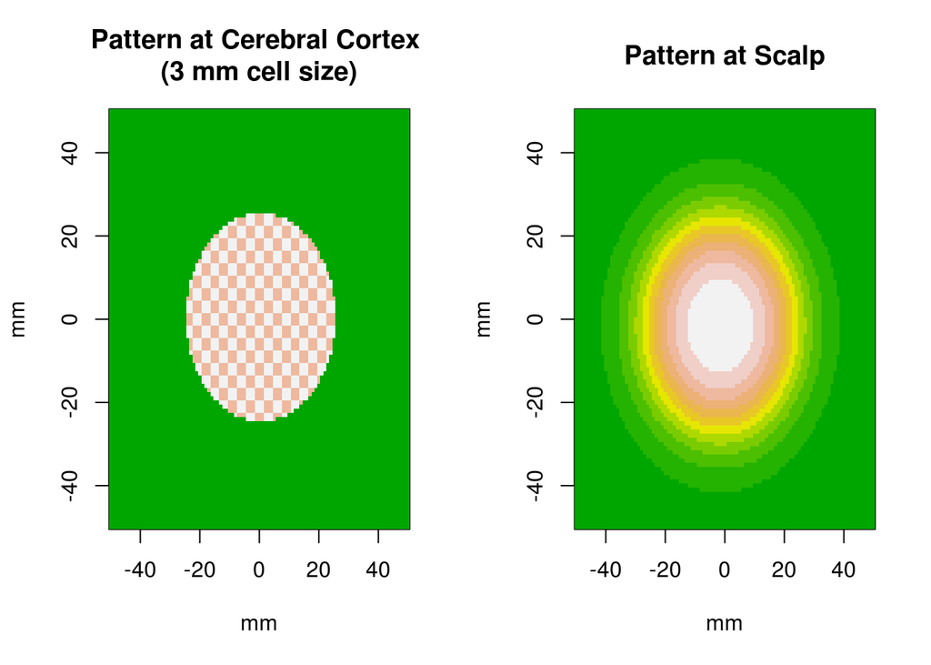

Without noise, other than the limits of computational precision, the original pattern can actually be recovered by deconvolution.

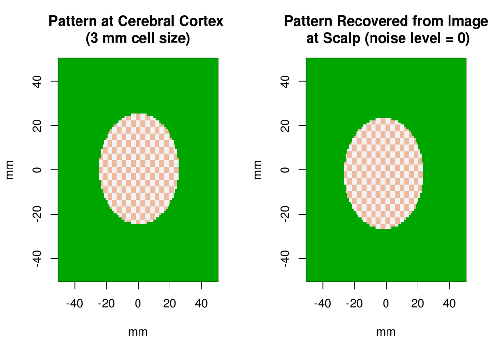

However, even very low noise levels at the scalp prevent recovery by simple deconvolution. This is to be expected, since simple deconvolution is a matter of dividing by eigenvalues of the cerebral-cortex-to-scalp transfer function. Assuming measurement and other noise added at the scalp is Gaussian and i.i.d., its 2D Fourier transform should be “white”, i.e., Gaussian and i.i.d with the same variance (since the Fourier transform is unitary.) Thus, dividing by the very small eigenvalues at high spatial frequencies will greatly amplify the noise at those frequencies. The effect can be seen from the graininess of reconstruction.

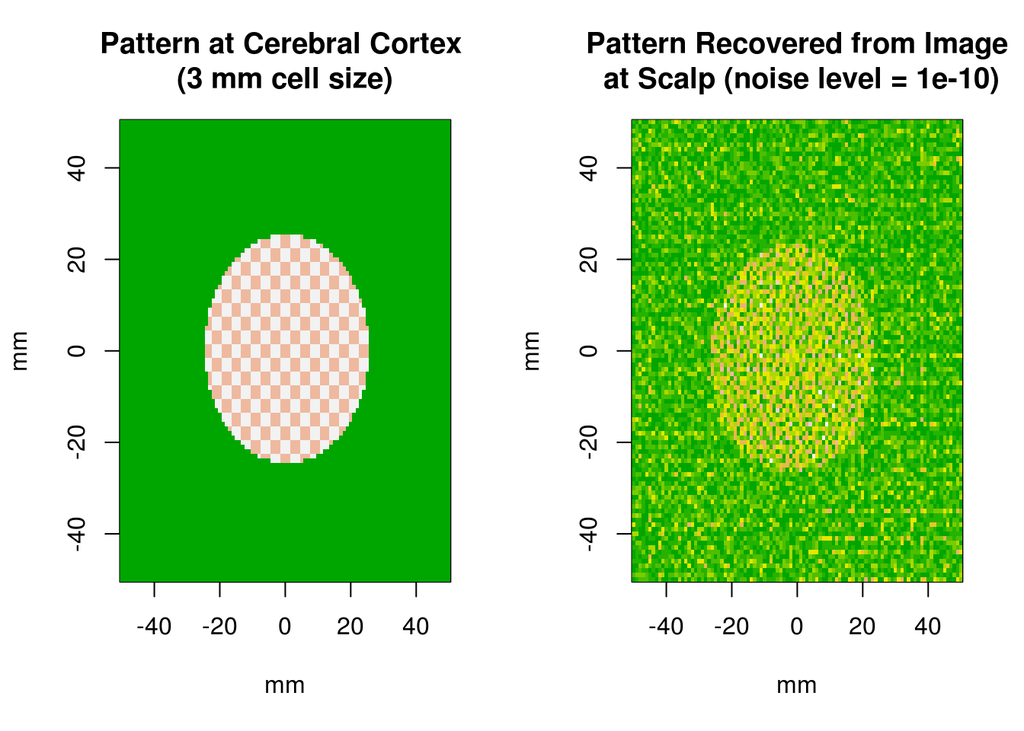

Simple deconvolution is far from optimal. Reconstruction by linear regression would be better, since it would avoid division by small eigenvalues, but it would not recover detail at high spatial frequencies either. At best, details which were buried in noise would be recovered as mean values.

download Rmd which includes source code for computations

download R file containing code for VSD spectra